# SHOEB ASSIGNMENT 6

### 1. What is a Hyperplane? and Explain how the Classification is done Using a Separating Hyperplane [15 pts]

Answer: If we have p-dimensional space, a hyperplane is a flat subspace with dimension p-1. For example, in two-dimensional space a hyperplane is a straight line, and in three-dimensional space, a hyperplane is a two-dimensional subspace.

Classification Using Separating hyperplane: Suppose we have one train and testing data matrix. The training data matrix have n×p dimensions. Meaning it has n observation and it is p dimensional. Each observation falls under either of the two classes, i.e. y1….yn can either be -1 or 1. Suppose if based on the training data, we can construct a hyperplane that can perfectly separate all training observations according to classes labeled.

### 2. What is Maximal Margin Classifier and explain the construction of Construction of the Maximal Margin Classifier in your own words? [15 Pts]

Answer:

Maximal Margin Classifier:

If we divide data based on hyperplane, then there could be many possible hyperplanes to divide same set of numbers. How do we decide the finite number of hyperplanes to choose from? The solution is Maximal Margin Classifier.

This is a classifier that is farthest from the training observations. By computing the perpendicular distance between the hyperplane to the training observations. The shortest such distance is called the minimal distance between the hyperplane and the observation, and it is called margin.

Therefore, maximal margin hyperplane is the hyperplane that has the largest margin, meaning, which has the largest distance between the hyperplane and the training observations. Using that hyperplane we can classify testing data. If our model has

B0+B1+...Bp as coefficients

then the maximal margin classifier can classify new test observations based on the sign of

f(x)

In simple words, for each testing observation we put all the variables in the equation above and decide which side of the hyperplane that particular observation belongs to, based on the sign of f(x).

The way maximal margin classifier looks like is that it has one plane that is cutting through the p-dimensional space and dividing it into two pieces, and then it has two lines, each on one and other side of that plane. Those lines are called margins, and the observations touching those two lines are called vectors. They are defining the length of the margin, farther those points are, farther away those two lines are from the middle hyperplane. Those touching points are called vectors because they are vectors in p-dimensional space.

Interestingly, this classifier simply depends upon those vectors and not on all other observations available in the training set. Meaning, if you move vectors, the classifier would change its margin, but if you move all other observations the margin wouldn’t change.

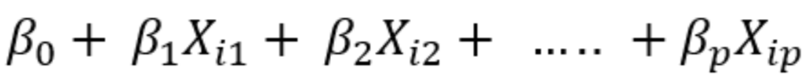

we get a value less than or greater than zero. Besides having a ± sign that value also have a magnitude, and if we multiply that magnitude with the labels of class it belongs to, then we get the distance of how far that point is from hyperplane. Interpretation: Define the values of all betas (beta1, beta2…beta_p) such that there is a margin M which has a maximum possible value, then classify each observation such that if you multiply its output (-1 or 1) with its equation

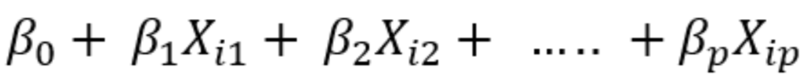

you get a positive number with some magnitude and that magnitude is greater than the distance M. Therefore, if you have a magnitude greater than M which is a largest possible margin than that number falls on that margin or farther from it.

### 3. Explain in detail the scenario of the Non-separable Case of the dataset and how is solved using SVM’s ? [15 Pts]

There may be some cases where the above approach will not work. To solve this problem of separating non-separable cases the concept of support vector classification comes up.There are cases where we cannot draw a boundary that can separate two classes in linear fashion.

In such cases, considering enlarging the feature space using functions of the predictors such as quadratic or cubic terms in order to address the non-linearity. In case of support vector classifier, we can address this problem of having possibility non-linear boundaries between classes in similar way by enlarging the feature space using quadratic, cubic or even higher-order polynomial. For example, if we have 2-D feature space with training observation having value (X1,Y1), (X1,Y1)….(X_n,Y_n) such that they are inseparable using a linear plane, then we can convert the feature space into a 3-D space by having a third-dimension (X1,Y1,Z1),(X2,Y2,Z2)…..(X_n,Y_n,Z_n)

In order words, rather than fitting a support vector classifier using p features we can instead fit a support vector classifier using 2p features.

The change in feature space can be anything one like to be as long as it is successfully converting the space into higher dimensional space such that two classes can be separated using linear plane. However, we need some kind of standardized computation method that can convert our feature space into higher dimension. Here comes the kernel trick.

### 4. Explain in detail about how SVMs is applied to case where More than Two Classes as present in the target variables?[15 Pts]

Support vector machines (SVMs) are a binary classifier that seeks to find the flat surface (a straight line in two dimensions) that separates the two levels of the target.

When the data contain more than two classes, a single flat surface cannot separate each group from the others. However, several surfaces can partition the observations from each other. How you find the surfaces depends on your approach in the multiclass SVM: one-versus-all or one-versus-one.

One-versus-All Training The one-versus-all approach to multiclass SVMs is to train k unique SVMs, where you have k classes of the target.To assign a class label to a new observation, you need to score the observation scored according to each SVM model. In this way, the new observation will have an assigned probability for each class of the target. If the observation is on the negative side of the dividing hyperplane, then its probability is less than 0.5. If it is on the positive side of the dividing hyperplane, then its probability is greater than 0.5.

One-versus-One Training The one-versus-one approach to multiclass SVMs is to train an SVM for each pair of target classes. When you have k classes, the number of SVMs to be trained is k*(k–1)/2. In one-versus-all scoring, each SVM model answers the question, Does this belong to the class or not? In one-versus-one scoring, each SVM model answers a different question: Is this more of class A or class B? Thus, using the maximum probability, as in one-versus-all scoring, is not the appropriate way to determine the class label assignment. In one-versus-one scoring, a common method of determining this assignment is by voting. Each observation is assigned a class label for each SVM model that is produced. The label that the observation is assigned the most is considered the true label.

### 5. a) Apply Support Vector Classifier on the given heart disease dataset ? The output should have your code, plots, accuracy, precision, recall, f1-score. b) Use different kernel methods available (Sigmoid, Gaussian, Polynomial) in the SVM and comment on the accuracy and performance using different kernels. For Dataset and it’s description check Icollege (15 pts part a , 15 points for part b )[40 Pts]

```python
import numpy as np
import pandas as pd
import seaborn as sns
import matplotlib.pyplot as plt
from sklearn.model_selection import train_test_split # Import train_test_split function
from sklearn import svm #Import svm model
from sklearn import metrics #Import scikit-learn metrics module for accuracy calculation
from sklearn.metrics import confusion_matrix

# Read heart csv file
data = pd.read_csv('heart.csv')
data.shape
```

```
(303, 14)
```

```python
# sample data
data.head()
```

|  | age | sex | cp | trestbps | chol | fbs | restecg | thalach | exang | oldpeak | slope | ca | thal | target |
| --- | --- | --- | --- | --- | --- | --- | --- | --- | --- | --- | --- | --- | --- | --- |
| 0 | 63 | 1 | 3 | 145 | 233 | 1 | 0 | 150 | 0 | 2.3 | 0 | 0 | 1 | 1 |
| 1 | 37 | 1 | 2 | 130 | 250 | 0 | 1 | 187 | 0 | 3.5 | 0 | 0 | 2 | 1 |
| 2 | 41 | 0 | 1 | 130 | 204 | 0 | 0 | 172 | 0 | 1.4 | 2 | 0 | 2 | 1 |
| 3 | 56 | 1 | 1 | 120 | 236 | 0 | 1 | 178 | 0 | 0.8 | 2 | 0 | 2 | 1 |
| 4 | 57 | 0 | 0 | 120 | 354 | 0 | 1 | 163 | 1 | 0.6 | 2 | 0 | 2 | 1 |

```python
data.describe()
```

|  | age | sex | cp | trestbps | chol | fbs | restecg | thalach | exang | oldpeak | slope | ca | thal | target |
| --- | --- | --- | --- | --- | --- | --- | --- | --- | --- | --- | --- | --- | --- | --- |
| count | 303.000000 | 303.000000 | 303.000000 | 303.000000 | 303.000000 | 303.000000 | 303.000000 | 303.000000 | 303.000000 | 303.000000 | 303.000000 | 303.000000 | 303.000000 | 303.000000 |
| mean | 54.366337 | 0.683168 | 0.966997 | 131.623762 | 246.264026 | 0.148515 | 0.528053 | 149.646865 | 0.326733 | 1.039604 | 1.399340 | 0.729373 | 2.313531 | 0.544554 |
| std | 9.082101 | 0.466011 | 1.032052 | 17.538143 | 51.830751 | 0.356198 | 0.525860 | 22.905161 | 0.469794 | 1.161075 | 0.616226 | 1.022606 | 0.612277 | 0.498835 |
| min | 29.000000 | 0.000000 | 0.000000 | 94.000000 | 126.000000 | 0.000000 | 0.000000 | 71.000000 | 0.000000 | 0.000000 | 0.000000 | 0.000000 | 0.000000 | 0.000000 |
| 25% | 47.500000 | 0.000000 | 0.000000 | 120.000000 | 211.000000 | 0.000000 | 0.000000 | 133.500000 | 0.000000 | 0.000000 | 1.000000 | 0.000000 | 2.000000 | 0.000000 |
| 50% | 55.000000 | 1.000000 | 1.000000 | 130.000000 | 240.000000 | 0.000000 | 1.000000 | 153.000000 | 0.000000 | 0.800000 | 1.000000 | 0.000000 | 2.000000 | 1.000000 |
| 75% | 61.000000 | 1.000000 | 2.000000 | 140.000000 | 274.500000 | 0.000000 | 1.000000 | 166.000000 | 1.000000 | 1.600000 | 2.000000 | 1.000000 | 3.000000 | 1.000000 |
| max | 77.000000 | 1.000000 | 3.000000 | 200.000000 | 564.000000 | 1.000000 | 2.000000 | 202.000000 | 1.000000 | 6.200000 | 2.000000 | 4.000000 | 3.000000 | 1.000000 |

```python
#Display basic info about the data
data.info()
```

```
<class 'pandas.core.frame.DataFrame'>
RangeIndex: 303 entries, 0 to 302
Data columns (total 14 columns):
 #   Column    Non-Null Count  Dtype
---  ------    --------------  -----
 0   age       303 non-null    int64
 1   sex       303 non-null    int64
 2   cp        303 non-null    int64
 3   trestbps  303 non-null    int64
 4   chol      303 non-null    int64
 5   fbs       303 non-null    int64
 6   restecg   303 non-null    int64
 7   thalach   303 non-null    int64
 8   exang     303 non-null    int64
 9   oldpeak   303 non-null    float64
 10  slope     303 non-null    int64
 11  ca        303 non-null    int64
 12  thal      303 non-null    int64
 13  target    303 non-null    int64
dtypes: float64(1), int64(13)
memory usage: 33.3 KB
```

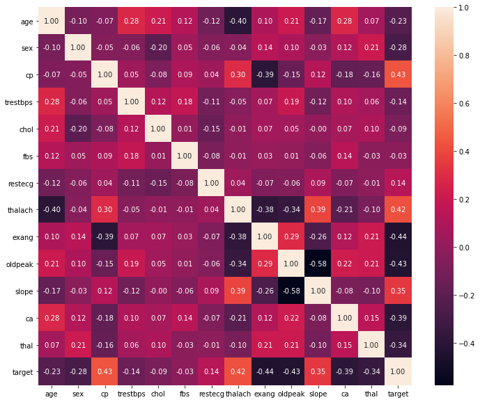

```python
plt.figure(figsize=(12,10))
sns.heatmap(data.corr(), annot= True, fmt='.2f')
plt.show();
```

[figure not shown]

```python
# Line Plot
# color = color, label = label, linewidth = width of line, alpha = opacity
# grid = grid, linestyle = sytle of line

data.thal.plot(kind = 'line', color = 'g', label = ' Thalassemia',linewidth = 1, alpha = 0.5, grid = True, linestyle = ':')
data.oldpeak.plot(color = 'r',label = 'Cholesterol',linewidth = 1, alpha = 0.5, grid = True, linestyle = '-.')
plt.legend(loc='upper right')
plt.xlabel('x axis')
plt.ylabel('y axis')
plt.title('Thalassemia-Cholesterol Plot')
plt.show()
```

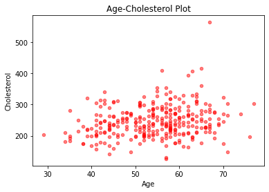

```python
# Scatter Plot
# x = Age, y = Cholesterol

data.plot(kind = 'scatter',x = 'age', y = 'chol',alpha = 0.5, color = 'red')
plt.xlabel('Age')
plt.ylabel('Cholesterol')
plt.title('Age-Cholesterol Plot')
```

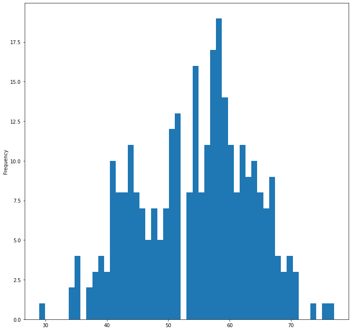

```python
# Histogram
# Age frequency in data
# bins = number of bar in figure

data.age.plot(kind = 'hist', bins = 50, figsize = (12,12))
plt.show()
```

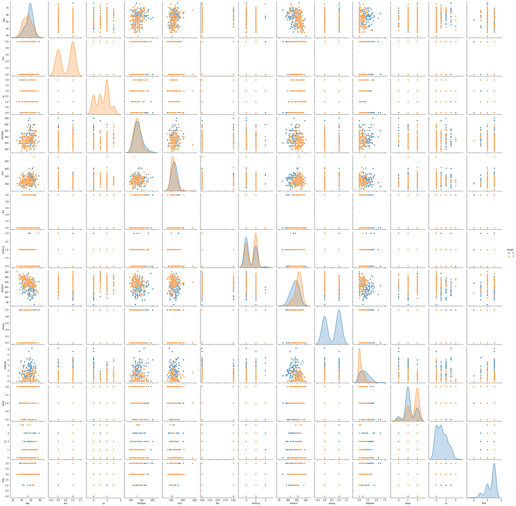

```python
sns.pairplot(data, hue = 'target');
```

```python
#Separate Feature and Target Matrix
x = data.drop('target',axis = 1)
y = data.target
```

```python
y.shape
```

```
(303,)
```

```python
# Split dataset into training set and test set
x_train, x_test, y_train, y_test = train_test_split(x, y, test_size=0.3,random_state=109) # 70% training and 30% test
```

```python
#Create a svm Classifier
ml = svm.SVC(kernel='linear') # Linear Kernel

#Train the model using the training sets
ml.fit(x_train, y_train)

#Predict the response for test dataset
y_pred = ml.predict(x_test)
```

```python
from sklearn.metrics import accuracy_score, f1_score, precision_score, recall_score, classification_report, confusion_matrix
# Model Accuracy: how often is the classifier correct?
print("accuracy:",ml.score(x_test,y_test))
print("f1_score:",f1_score(y_test, y_pred, average="macro"))
print("precision_score:",precision_score(y_test, y_pred, average="macro"))
print("recall_score",recall_score(y_test, y_pred, average="macro"))
```

```
accuracy: 0.9010989010989011
f1_score: 0.8993486542951947
precision_score: 0.9006410256410257
recall_score 0.8982843137254901
```

```python
confusion_matrix(y_test,y_pred)
```

```
array([[35,  5],
       [ 4, 47]], dtype=int64)
```

5 patients were predicted that they will have Heart Disease but the Prediction was WRONG (False-Positive)

4 patients were predicted that they will NOT have Heart Disease but the Prediction was WRONG (False-Negative)

```python
#Create a svm Classifier
ml = svm.SVC(kernel='sigmoid') # sigmoid Kernel

#Train the model using the training sets
ml.fit(x_train, y_train)

#Predict the response for test dataset
y_pred = ml.predict(x_test)
```

```python
from sklearn.metrics import accuracy_score, f1_score, precision_score, recall_score, classification_report, confusion_matrix
# Model Accuracy: how often is the classifier correct?
print("accuracy:",ml.score(x_test,y_test))
print("f1_score:",f1_score(y_test, y_pred, average="macro"))
print("precision_score:",precision_score(y_test, y_pred, average="macro"))
print("recall_score",recall_score(y_test, y_pred, average="macro"))
```

```
accuracy: 0.5604395604395604
f1_score: 0.3591549295774648
precision_score: 0.2802197802197802
recall_score 0.5
```

```python
confusion_matrix(y_test,y_pred)
```

```
array([[ 0, 40],
       [ 0, 51]], dtype=int64)
```

```python
print(classification_report(y_test, y_pred))
```

```
              precision    recall  f1-score   support

           0       0.00      0.00      0.00        40
           1       0.56      1.00      0.72        51

    accuracy                           0.56        91
   macro avg       0.28      0.50      0.36        91
weighted avg       0.31      0.56      0.40        91
```

```python
#Create a svm Classifier
ml = svm.SVC(kernel='poly') # polynomial Kernel

#Train the model using the training sets
ml.fit(x_train, y_train)

#Predict the response for test dataset
y_pred = ml.predict(x_test)
```

```python
from sklearn.metrics import accuracy_score, f1_score, precision_score, recall_score, classification_report, confusion_matrix
# Model Accuracy: how often is the classifier correct?
print("accuracy:",ml.score(x_test,y_test))
print("f1_score:",f1_score(y_test, y_pred, average="macro"))
print("precision_score:",precision_score(y_test, y_pred, average="macro"))
print("recall_score",recall_score(y_test, y_pred, average="macro"))
```

```
accuracy: 0.6703296703296703
f1_score: 0.6584084084084084
precision_score: 0.6656346749226006
recall_score 0.6573529411764706
```

```python
confusion_matrix(y_test,y_pred)
```

```
array([[22, 18],
       [12, 39]], dtype=int64)
```

```python
print(classification_report(y_test, y_pred))
```

```
              precision    recall  f1-score   support

           0       0.65      0.55      0.59        40
           1       0.68      0.76      0.72        51

    accuracy                           0.67        91
   macro avg       0.67      0.66      0.66        91
weighted avg       0.67      0.67      0.67        91
```

```python
#Create a svm Classifier
ml = svm.SVC(kernel='rbf') # gaussian Kernel

#Train the model using the training sets
ml.fit(x_train, y_train)

#Predict the response for test dataset
y_pred = ml.predict(x_test)
```

```python
from sklearn.metrics import accuracy_score, f1_score, precision_score, recall_score, classification_report, confusion_matrix
# Model Accuracy: how often is the classifier correct?
print("accuracy:",ml.score(x_test,y_test))
print("f1_score:",f1_score(y_test, y_pred, average="macro"))
print("precision_score:",precision_score(y_test, y_pred, average="macro"))
print("recall_score",recall_score(y_test, y_pred, average="macro"))
```

```
accuracy: 0.6923076923076923
f1_score: 0.6671891327063741
precision_score: 0.7038461538461538
recall_score 0.6688725490196079
```

```python
confusion_matrix(y_test,y_pred)
```

```
array([[19, 21],
       [ 7, 44]], dtype=int64)
```

```python
print(classification_report(y_test, y_pred))
```

```
              precision    recall  f1-score   support

           0       0.73      0.47      0.58        40
           1       0.68      0.86      0.76        51

    accuracy                           0.69        91
   macro avg       0.70      0.67      0.67        91
weighted avg       0.70      0.69      0.68        91
```

Amongst the Gaussian kernel and polynomial kernel, we can see that Gaussian kernel achieved a better prediction rate than polynomial kernel. Therefore the Gaussian kernel performed slightly better. However, there is no hard and fast rule as to which kernel performs best in every scenario. It is all about testing all the kernels and selecting the one with the best results on your test dataset.